# Defining a single Plasmid sample for a Plasmid batch sequenced several times

Alex Kalinka

20 March, 2020

# 1 Setup

```r
options(warn=-1)
set.seed(1)

suppressMessages(library(knitr))
suppressMessages(library(grid))
suppressMessages(library(gridExtra))
suppressMessages(library(tidyr))
suppressMessages(library(magrittr))
suppressMessages(library(readr))
suppressMessages(library(ggplot2))
suppressMessages(library(GGally))
suppressMessages(library(dplyr))
suppressMessages(library(moments))

select <- dplyr::select
filter <- dplyr::filter
rename <- dplyr::rename

base_path <- "~/data/az_cruk"
ht29_path <- file.path(base_path,"ht29/crisprn/plasmid_test/counts")

# Plasmid counts for Yusa v3 AZ batch 1.
pl_counts_batch_1 <- read.table(file.path(ht29_path,"combined_counts.txt"),
                                stringsAsFactors = F, header = T) %>%
  select(sgRNA, gene, FGC_AZ_001_3, FGC_AZ_001_4) %>%
  left_join(read.table(file.path(ht29_path,"Plasmid_AZ_1.s_1.counts"),
                       header = F, stringsAsFactors = F) %>%
              select(-V2), by = c("sgRNA"="V1")) %>%
  left_join(read.table(file.path(ht29_path,"Plasmid_AZ_2.s_1.counts"),
                       header = F, stringsAsFactors = F) %>%
              select(-V2), by = c("sgRNA"="V1")) %>%
  rename(Plasmid_AZ_1 = V3.x, Plasmid_AZ_2 = V3.y)

# Other library plasmid counts for Library Width comparisons.
yusa_v1_pl_counts <- read.csv(file.path(base_path,"plasmid_counts/Yusa_v1_human_plasmid_counts.csv"),
                              stringsAsFactors = F)
brunello_pl_counts <- read.csv(file.path(base_path,"plasmid_counts/Brunello_human_plasmid_counts.csv"),
                              stringsAsFactors = F)
whitehead_conv_pl_counts <- read.csv(file.path(base_path,"plasmid_counts/Whitehead_conv_human_plasmid_counts.csv"),
                              stringsAsFactors = F)
whitehead_imprv_pl_counts <- read.csv(file.path(base_path,"plasmid_counts/Whitehead_imprv_human_plasmid_counts.csv"),
                              stringsAsFactors = F)

# Yusa with gRNA sequences.
yusa.v3 <- read.table("~/data/az_cruk/cleanr.tsv", stringsAsFactors = F, header=T) %>%
  rowwise() %>%
  mutate(GC_percent = 100*(sum(unlist(strsplit(seq,"")) == "G") + sum(unlist(strsplit(seq,"")) == "C"))/19,
         pam_upstream4 = substr(seq,16,19),
         proximal_4bases_pam = case_when(grepl("TT",pam_upstream4) ~ "TT",
                                         grepl("GCC",pam_upstream4) ~ "GCC",
                                         TRUE ~ "Other")) %>%
  ungroup()

# QC screen logfc.
lfc.bl <- read.table("../data/qc_screen.cleanr.logfc.baseline.tsv", header=T, stringsAsFactors = F)
lfc.d7 <- read.table("../data/qc_screen.cleanr.logfc.day7.tsv", header=T, stringsAsFactors = F)
lfc.d14 <- read.table("../data/qc_screen.cleanr.logfc.day14.tsv", header=T, stringsAsFactors = F)
```

# 2 Summarise plasmid counts

**Approach**:

- Relativise the plasmid samples so that they each sum to 1.
- Multiply by the median total library depth.
- Take the rounded median across each sgRNA.

The summarised plasmid sample will be referred to as **Plasmid FGC batch 1**.

```r
lib_depth <- colSums(pl_counts_batch_1[,3:6])
median_lib_depth <- median(lib_depth)

pl_relat <- pl_counts_batch_1 %>%
  mutate(FGC_AZ_001_3 = median_lib_depth*FGC_AZ_001_3/lib_depth[1],
         FGC_AZ_001_4 = median_lib_depth*FGC_AZ_001_4/lib_depth[2],
         Plasmid_AZ_1 = median_lib_depth*Plasmid_AZ_1/lib_depth[3],
         Plasmid_AZ_2 = median_lib_depth*Plasmid_AZ_2/lib_depth[4])

pl_summ <- pl_relat %>%
  rowwise() %>%
  mutate(Plasmid_FGC_batch_1 = as.integer(round(median(c(FGC_AZ_001_3,FGC_AZ_001_4,
                                                 Plasmid_AZ_1,Plasmid_AZ_2))))) %>%
  ungroup() %>%
  arrange(sgRNA)


cat("Sanity checks:\nPearson correlation between plasmid samples:\n(expect 'Plasmid_FGC_batch_1' to have high correlations with original plasmid samples)\n")
```

```
## Sanity checks:
## Pearson correlation between plasmid samples:
## (expect 'Plasmid_FGC_batch_1' to have high correlations with original plasmid samples)
```

```r
kable(cor(pl_summ[,3:7]))
```

|  | FGC_AZ_001_3 | FGC_AZ_001_4 | Plasmid_AZ_1 | Plasmid_AZ_2 | Plasmid_FGC_batch_1 |
| --- | --- | --- | --- | --- | --- |
| FGC_AZ_001_3 | 1.0000000 | 0.9929697 | 0.9917927 | 0.9896363 | 0.9967087 |
| FGC_AZ_001_4 | 0.9929697 | 1.0000000 | 0.9925765 | 0.9904022 | 0.9972096 |
| Plasmid_AZ_1 | 0.9917927 | 0.9925765 | 1.0000000 | 0.9907023 | 0.9969518 |
| Plasmid_AZ_2 | 0.9896363 | 0.9904022 | 0.9907023 | 1.0000000 | 0.9952367 |
| Plasmid_FGC_batch_1 | 0.9967087 | 0.9972096 | 0.9969518 | 0.9952367 | 1.0000000 |

```r
cat("Number of NA counts in 'Plasmid_FGC_batch_1':\n",sum(is.na(pl_summ$Plasmid_FGC_batch_1)))
```

```
## Number of NA counts in 'Plasmid_FGC_batch_1':
##  0
```

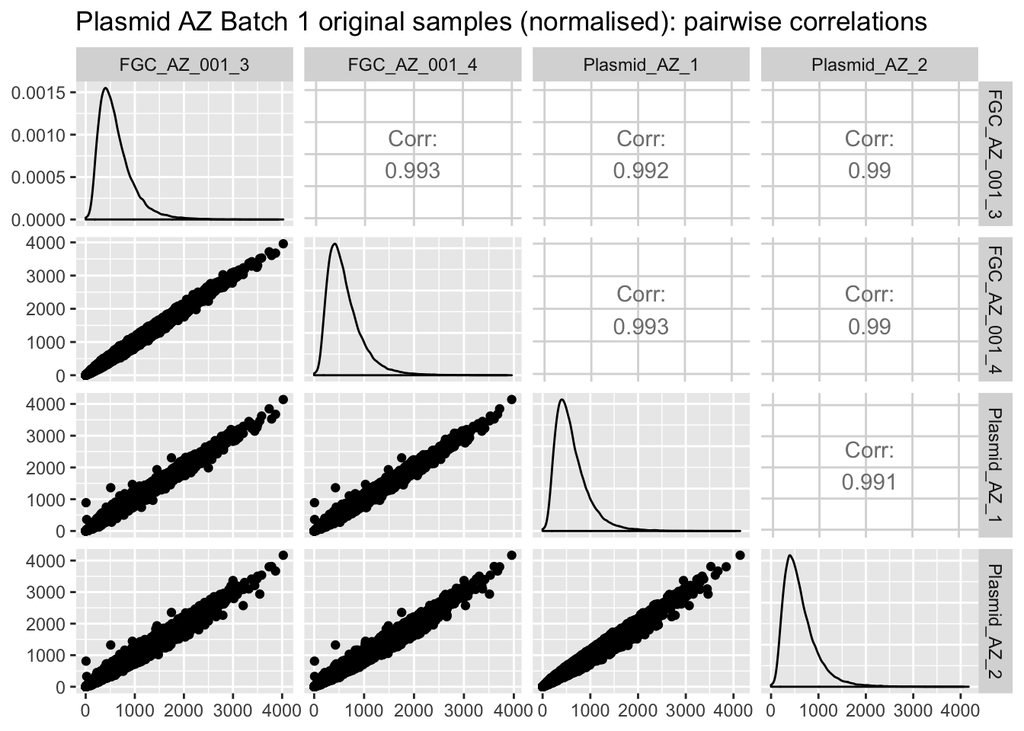

```r
# Save.
write.table(pl_summ %>%
              select(sgRNA, gene, Plasmid_FGC_batch_1),
            "../data/Yusa_v3_KO_Plasmid_FGC_batch_1--summarised.txt",
            quote=F, col.names = T, row.names = F, sep="\t")

write.table(pl_summ %>%
              select(sgRNA, gene, Plasmid_FGC_batch_1),
            "../data/Yusa_v3_KO_Plasmid_FGC_batch_1--summarised--no-header.txt",
            quote=F, col.names = F, row.names = F, sep="\t")

ggpairs(pl_summ[,3:6]) +
  ggtitle("Plasmid AZ Batch 1 original samples (normalised): pairwise correlations")
```

# 3 Plasmid FGC batch 1 analysis

## 3.1 Distribution

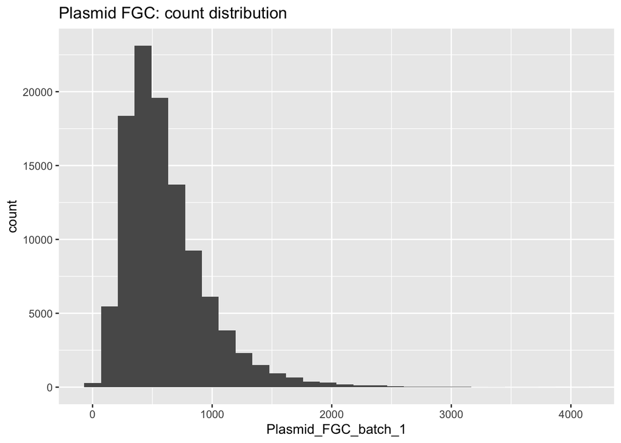

```r
pl <- ggplot(pl_summ, aes(Plasmid_FGC_batch_1)) +
  geom_histogram() +
  ggtitle("Plasmid FGC: count distribution")

suppressMessages(print(pl))
```

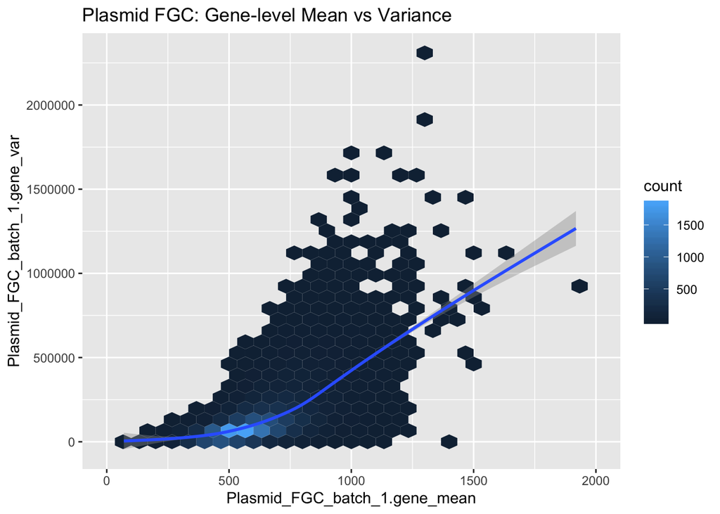

```r
pl <- pl_summ %>%
  group_by(gene) %>%
  summarise(Plasmid_FGC_batch_1.gene_mean = mean(Plasmid_FGC_batch_1),
            Plasmid_FGC_batch_1.gene_var = var(Plasmid_FGC_batch_1)) %>%
  ungroup %>%
  ggplot(aes(Plasmid_FGC_batch_1.gene_mean, Plasmid_FGC_batch_1.gene_var)) +
  geom_hex() +
  geom_smooth() +
  xlim(0,2000) +
  ggtitle("Plasmid FGC: Gene-level Mean vs Variance")

suppressMessages(print(pl))
```

## 3.2 Number of low-count guides

```r
cat("Number of zero-count gRNAS:\n",sum(pl_summ$Plasmid_FGC_batch_1==0))
```

```
## Number of zero-count gRNAS:
##  20
```

```r
cat("Number of gRNAS < 30 counts:\n",sum(pl_summ$Plasmid_FGC_batch_1<30))
```

```
## Number of gRNAS < 30 counts:
##  113
```

## 3.3 Plasmid Library Width

Based on a simple metric proposed in `gscreend` paper (Imkeller et al. 2020).

```r
get_library_distr_width <- function(data){
  lwd <- quantile(data, 0.9)/quantile(data, 0.1)
  names(lwd) <- NULL
  return(lwd)
}

cat("Library distribution width comparisons:\n")
```

```
## Library distribution width comparisons:
```

```r
kable(rbind(data.frame(Library = "Yusa v3",Batch = "Plasmid FGC Batch 1 summarised",
                       Library_Width = get_library_distr_width(pl_summ$Plasmid_FGC_batch_1)),
                  data.frame(Library = "Yusa v1",Batch= "Ong et al. 2017",
                             Library_Width = get_library_distr_width(yusa_v1_pl_counts$Plasmid)),
                  data.frame(Library = "Brunello",Batch="Ong et al. 2017",
                             Library_Width = get_library_distr_width(brunello_pl_counts$Plasmid)),
                  data.frame(Library = "Whitehead conv",Batch="Ong et al. 2017",
                             Library_Width = get_library_distr_width(whitehead_conv_pl_counts$Plasmid)),
                  data.frame(Library = "Whitehead imprv",Batch="Ong et al. 2017",
                             Library_Width = get_library_distr_width(whitehead_imprv_pl_counts$Plasmid)))
)
```

| Library | Batch | Library_Width |
| --- | --- | --- |
| Yusa v3 | Plasmid FGC Batch 1 summarised | 4.085271 |
| Yusa v1 | Ong et al. 2017 | 7.590000 |
| Brunello | Ong et al. 2017 | 4.160920 |
| Whitehead conv | Ong et al. 2017 | 3.837963 |
| Whitehead imprv | Ong et al. 2017 | 3.897849 |

According to **Figure 4H** in Imkeller et al. (2020), we are at the better end of the library width spectrum for achieving high recall (sensitivity) with relatively low splitting coverage:

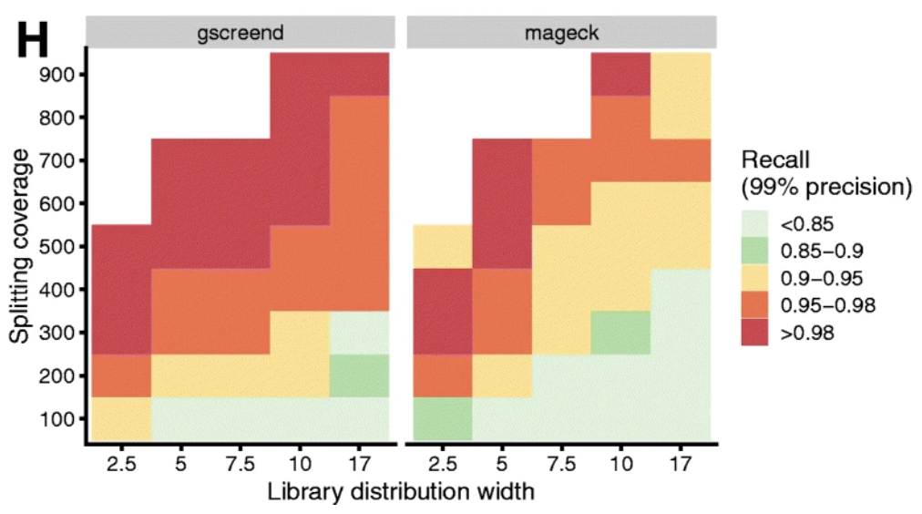

## 3.4 GC content vs counts

Estimating the impact of GC content on sgRNA counts. The plot below shows that there is a positive non-linear GC bias, and that below a GC content of ~30%-35% there is a steep drop in gRNA counts. We could consider one or both of the following:

- Applying a GC content correction
- Excluding gRNAs with a GC content below ~35%.

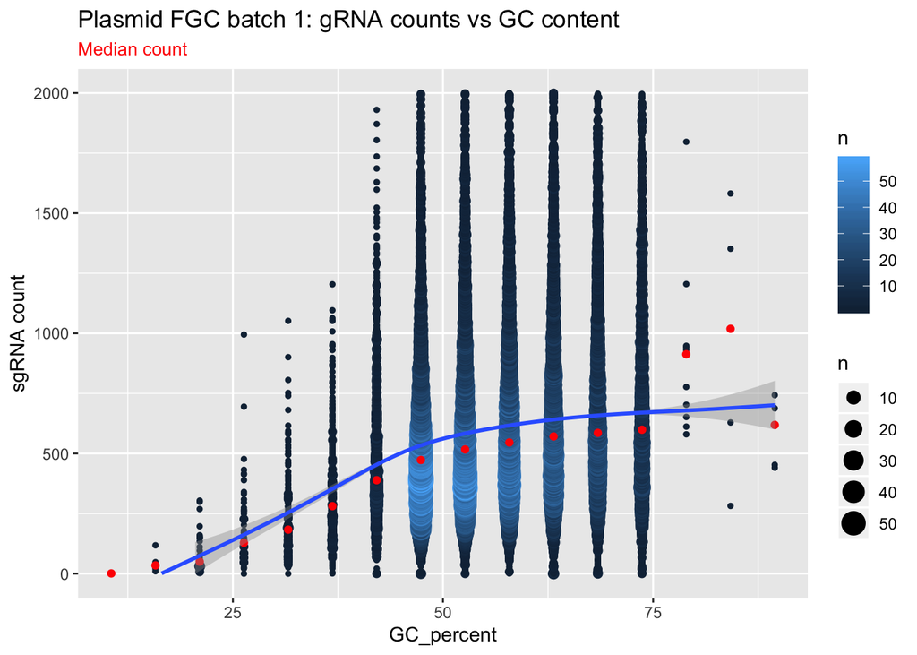

```r
pl_gc <- pl_summ %>%
  left_join(yusa.v3, by = c("sgRNA" = "CODE")) %>%
  group_by(GC_percent) %>%
  mutate(median_count = as.integer(round(median(Plasmid_FGC_batch_1, na.rm=T)))) %>%
  ungroup()

pl <- ggplot(pl_gc, aes(GC_percent, Plasmid_FGC_batch_1)) +
  geom_count(aes(color = ..n..)) +
  stat_summary(aes(y = Plasmid_FGC_batch_1), fun.y = median, color = "red", geom="point") +
  geom_smooth() +
  ylim(0,2000) +
  ylab("sgRNA count") +
  ggtitle("Plasmid FGC batch 1: gRNA counts vs GC content", subtitle = "Median count") +
  theme(plot.subtitle = element_text(color="red", size=10))

suppressMessages(print(pl))
```

## 3.5 GC content vs logFC (HT-29 QC screen 1)

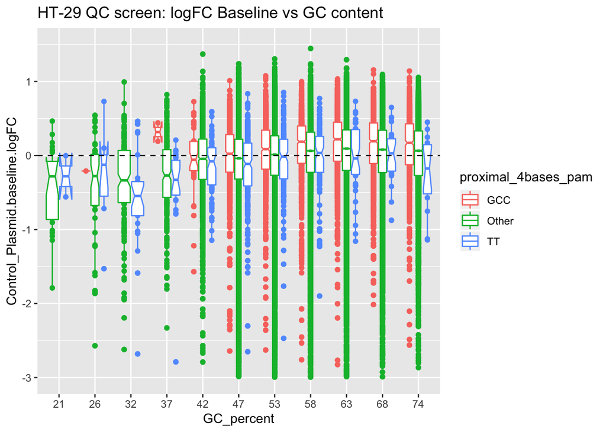

```r
pl_gc %<>%
  mutate(Control_Plasmid.baseline.logFC = lfc.bl$correctedFC[match(sgRNA,lfc.bl$SEQID)],
         Control_Plasmid.day7.logFC = lfc.d7$correctedFC[match(sgRNA,lfc.d7$SEQID)],
         Control_Plasmid.day14.logFC = lfc.d14$correctedFC[match(sgRNA,lfc.d14$SEQID)])

pl <- ggplot(pl_gc %>%
               dplyr::filter(between(GC_percent,20,75)) %>%
               mutate(GC_percent = factor(round(GC_percent))),
             aes(GC_percent, Control_Plasmid.baseline.logFC, color=proximal_4bases_pam)) +
  geom_point(position = position_dodge(width=0.75)) +
  geom_boxplot(notch=T) +
  ylim(-3,1.5) +
  geom_hline(yintercept = 0, linetype="dashed") +
  ggtitle("HT-29 QC screen: logFC Baseline vs GC content")

suppressMessages(print(pl))
```

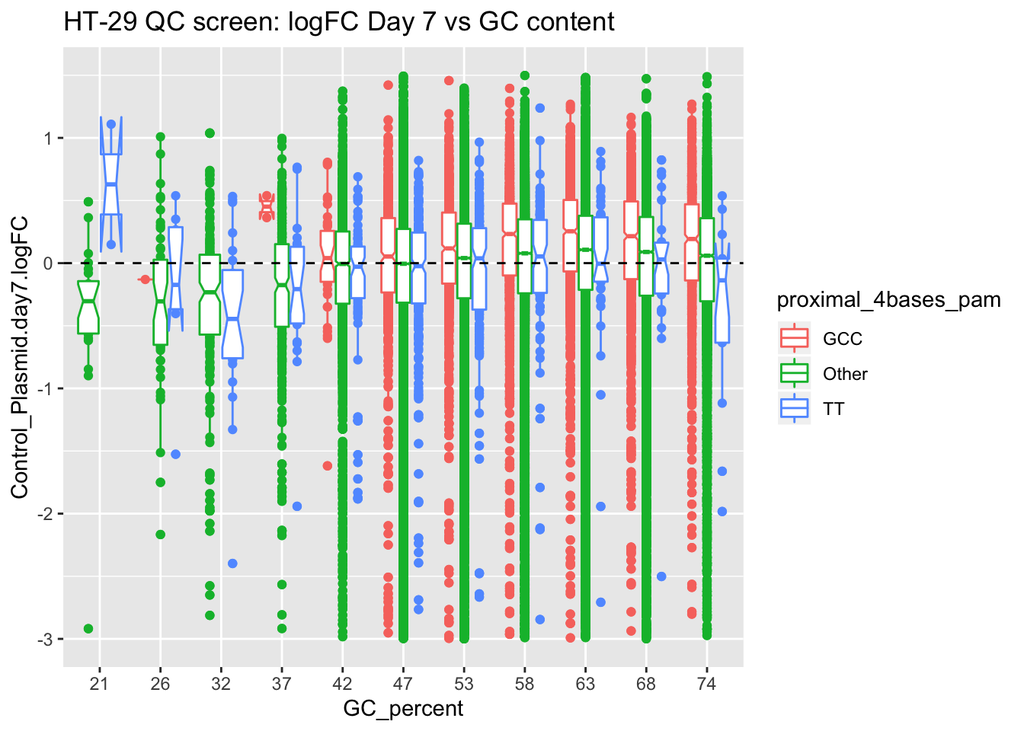

```r
pl <- ggplot(pl_gc %>%
               dplyr::filter(between(GC_percent,20,75)) %>%
               mutate(GC_percent = factor(round(GC_percent))),
             aes(GC_percent, Control_Plasmid.day7.logFC, color=proximal_4bases_pam)) +
  geom_point(position = position_dodge(width=0.75)) +
  geom_boxplot(notch=T) +
  ylim(-3,1.5) +
  geom_hline(yintercept = 0, linetype="dashed") +
  ggtitle("HT-29 QC screen: logFC Day 7 vs GC content")

suppressMessages(print(pl))
```

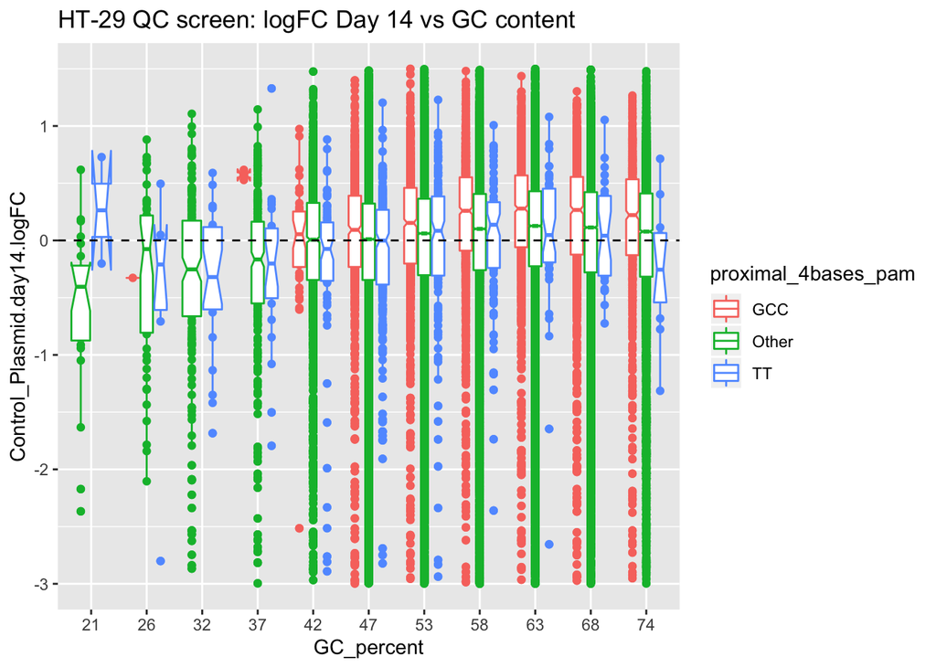

```r
pl <- ggplot(pl_gc %>%
               dplyr::filter(between(GC_percent,20,75)) %>%
               mutate(GC_percent = factor(round(GC_percent))),
             aes(GC_percent, Control_Plasmid.day14.logFC, color=proximal_4bases_pam)) +
  geom_point(position = position_dodge(width=0.75)) +
  geom_boxplot(notch=T) +
  ylim(-3,1.5) +
  geom_hline(yintercept = 0, linetype="dashed") +
  ggtitle("HT-29 QC screen: logFC Day 14 vs GC content")

suppressMessages(print(pl))
```

## 3.6 Library skewness using Sarle’s metric

Sarle’s bimodality metric ranges from 0-1 with higher values indicating more bimodal or skewed distributions - below I compare it to 100 random Gaussian distributions of the same size.

```r
calc_sarles_bimod <- function(data){
  return((skewness(data)^2+1)/kurtosis(data))
}

random_sb <- function(num = 100){
  return(sapply(1:num, function(x) calc_sarles_bimod(rnorm(nrow(pl_summ)))))
}

sb <- (skewness(pl_summ$Plasmid_FGC_batch_1)^2+1)/kurtosis(pl_summ$Plasmid_FGC_batch_1)

cat("Sarle's bimodality metric:\n",sb)
```

```
## Sarle's bimodality metric:
##  0.4890138
```

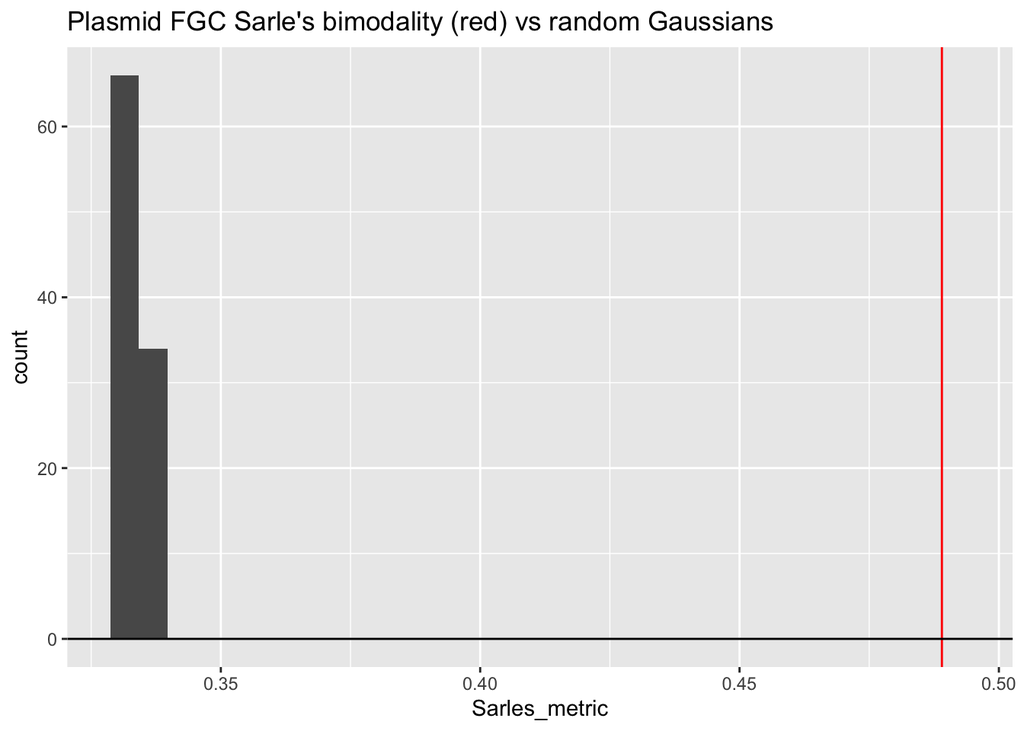

```r
rsb <- random_sb()

pl <- data.frame(Sarles_metric = rsb) %>%
  ggplot(aes(Sarles_metric)) +
  geom_histogram() +
  geom_vline(xintercept = sb, color = "red") +
  geom_hline(yintercept = 0) +
  ggtitle("Plasmid FGC Sarle's bimodality (red) vs random Gaussians")

suppressMessages(print(pl))
```

# 4 References

Imkeller, K. et al. 2020. gscreend: modelling asymmetric count ratios in CRISPR screens to decrease experiment size and improve phenotype detection. *Genome Biol* **21**, 53.

Ong, S. et al. 2017. Optimised metrics for CRISPR-KO screens with second-generation gRNA libraries. *Scientific Reports* **7**, 7384.